### 7.3.1 저장소의 지정

- 드퐅트는 `fig.path='figure/'`로 설정되어 있음
- 문서를 컴파일하고 나서 현재 폴더의 figure 디렉터리가 있는 지를 확인하고, 이름이 어떻게 부여되는 지 확인하는 것이 좋다.

````
```{r }
hist(rnorm(1000))
```
````

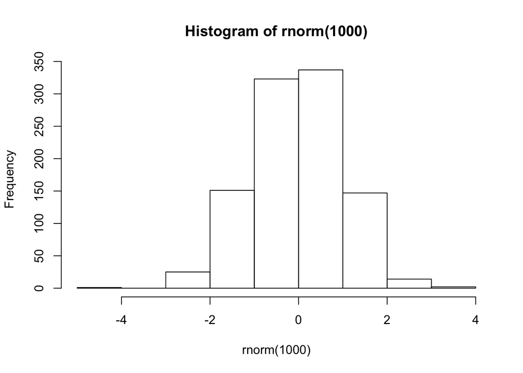

### 7.3.2 그래픽 디바이스 설정

- 그래픽 디바이이스는 `dev=` 옵션을 사용한다.
- 이 파일과 같이 .Rmd인 경우에는 png가 사용된다. LaTeX인 경우에는 pdf가 사용된다.
- 앞서 설명한 figure 폴더에 보면 그래프 확장자가 .png 임을 확인한다.

### 7.3.3 그래프의 크기 조절

- 그래프의 크기는 디퐅트로 7(인치)로 설정되어 있다. 바로 전의 코드 청크가 만는 결과를 확인하면 된다.
- 그래픽 디바이스를 기준으로 정할 수도 있고, 출력물을 기준으로 정할 수 있다.

### 7.3.4 그래픽 디바이스를 기준으로 크기 결정

- 그래픽 디바이스를 기준으로 할 때는 `fig.width=`, `fig.height=` 옵션을 사용한다. 인치 단위의 숫자를 주면 된다.

````
```{r fig.width=6, fig.height=3}
library(ggplot2)
data(iris)
ggplot(iris, aes(Sepal.Length, Sepal.Width, col=Species))+geom_point()
```
````

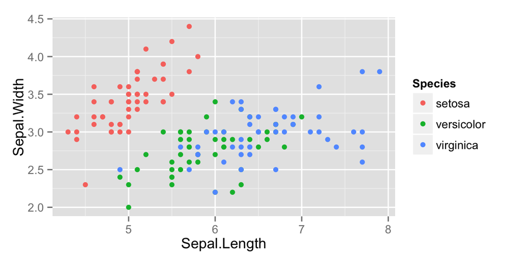

### 7.3.5 출력물을 기준으로 그래프 크기 결정

- 출력물을 기준으로 할 때는 `out.width=`, `out.height=` 옵션을 사용하는데 단위를 붙힌 문자열로 지정한다.

````
```{r withiris, out.width='500px', out.height='500px'}
p<-ggplot(iris, aes(Sepal.Length, Sepal.Width, col=Species))
p+geom_point()
```
````

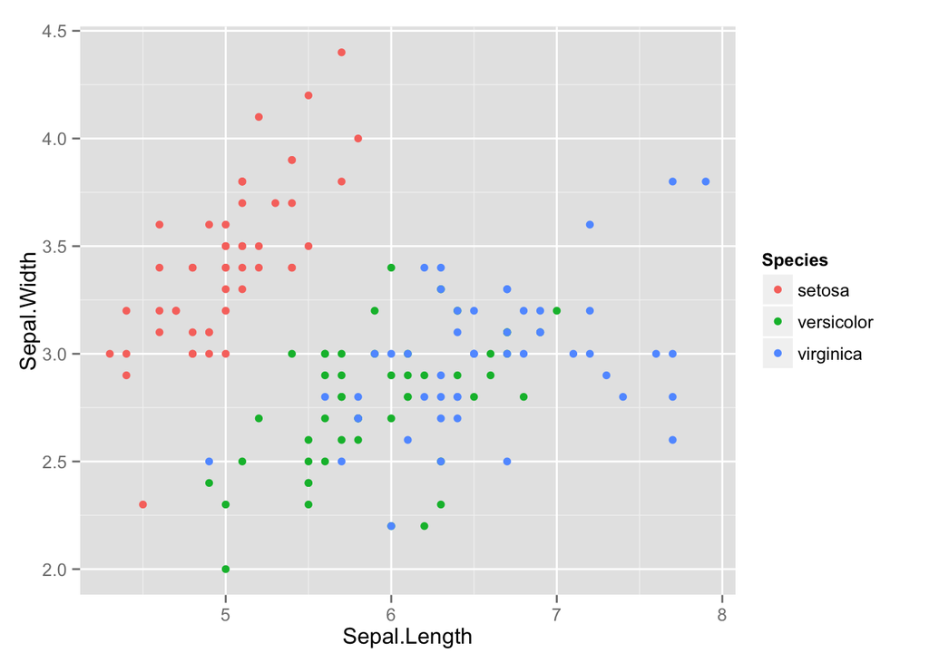

### 7.3.6 한 코드 청크에서 여러 그래프를 저장하는 방법

- 디폴트는 `fig.keep='high'`이다. 여기서 말하는 `high`라는 단어는 R 그래픽 시스템에서 고수준 함수(high-level function)에서 나온 것이다.
- 아래의 코드 청크에서 고수준 함수는 `hist()`와 `plot()`이기 때문에 이들 함수를 기준으로 그래프가 생성된다.
- 책에 옵션 값들이 대문자로 시작되는 것은 오류이다. 소문자가 맞다. (죄송합니다.)
- RStudio에서 코드 청크 옵션을 넣을 때 등호까지 입력하면 자동으로 선택가능한 값들을 보여주는 기능이 있어서 무척 편리하다.

````
```{r }
par(mfrow=c(2,1))
set.seed(7)
random <- rnorm(1000)
hist(random, prob=TRUE)
lines(density(random), col='red')

plot(mpg~wt, data=mtcars)
abline(lm(mpg~wt, data=mtcars), col='red')
```
````

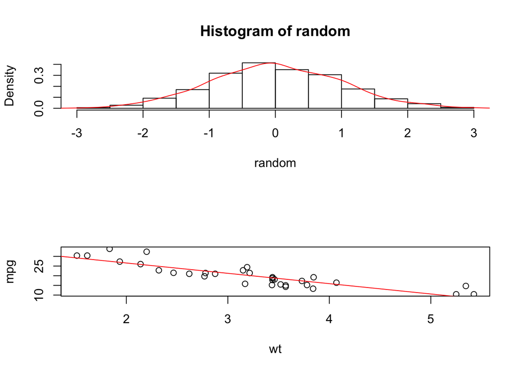

- 만약 `fig.keep='all'`로 주면 고수준, 저수준 함수의 효과가 모든 반영되어 그래프가 생성되는 전체 과정을 보여 준다. 코드 청크가 출력되는 것도 거기에 맞춰진다.

[output not shown]

[output not shown]

[output not shown]

[output not shown]

### 7.3.7 복수의 그래프에 다른 옵션 값 설정

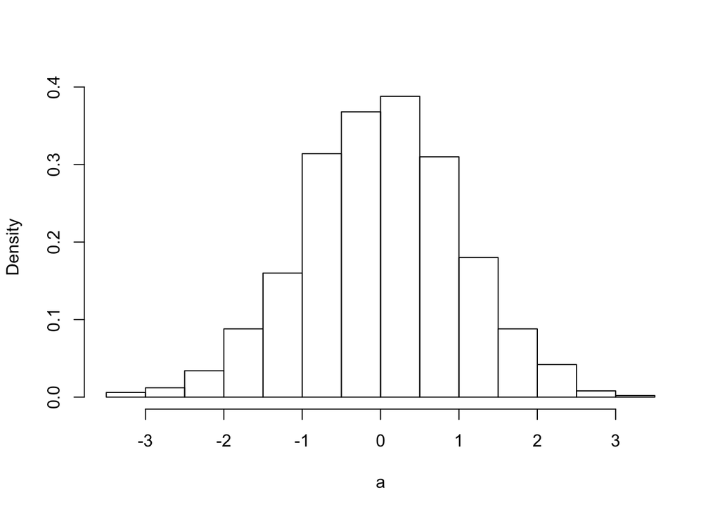

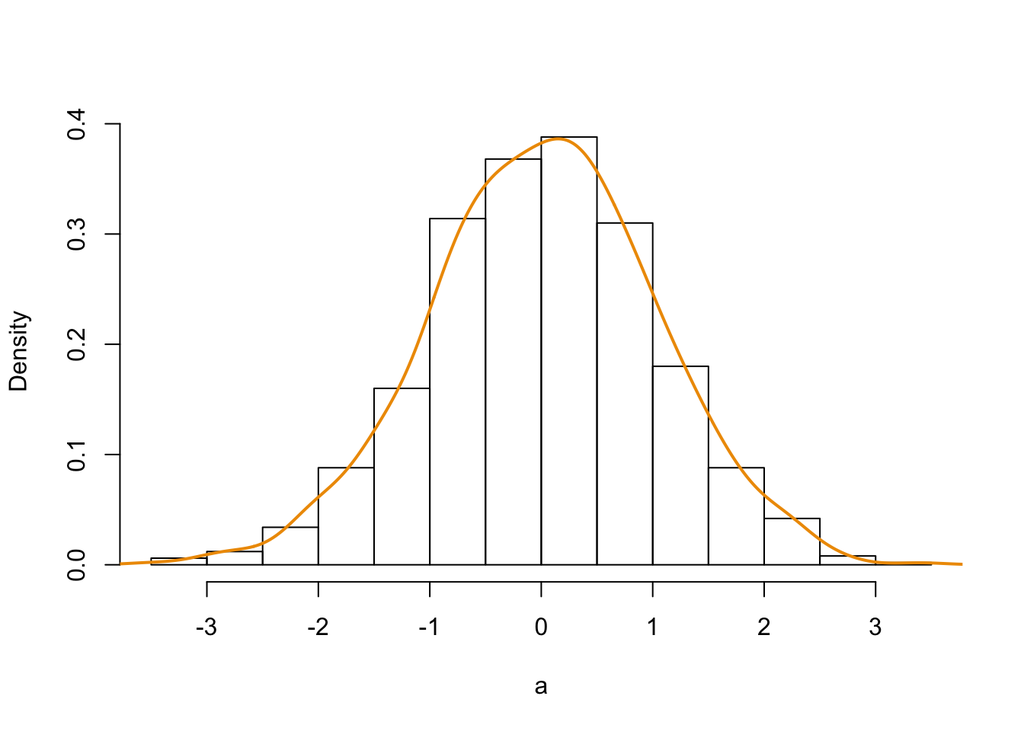

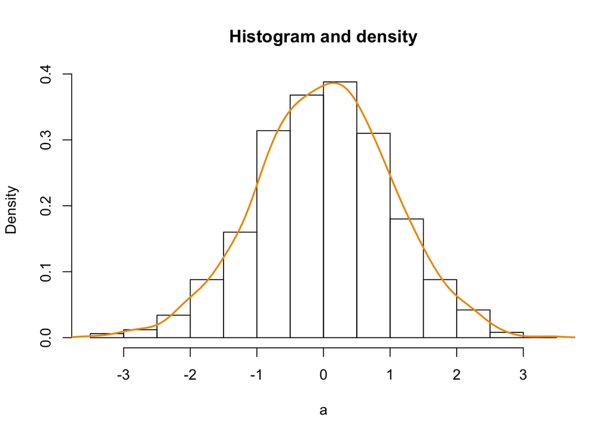

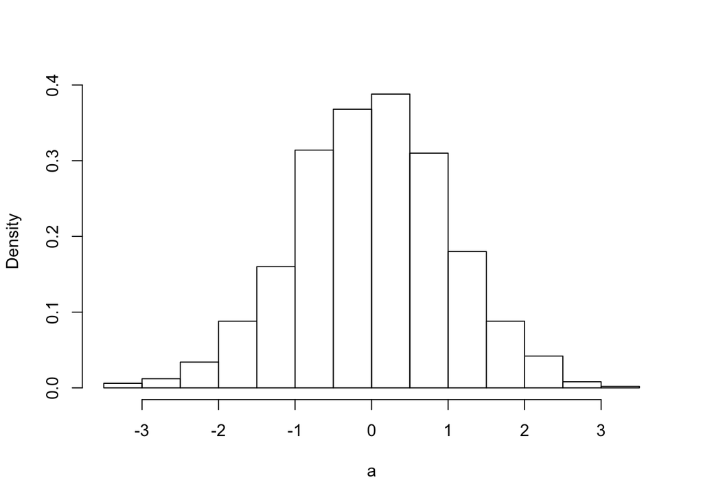

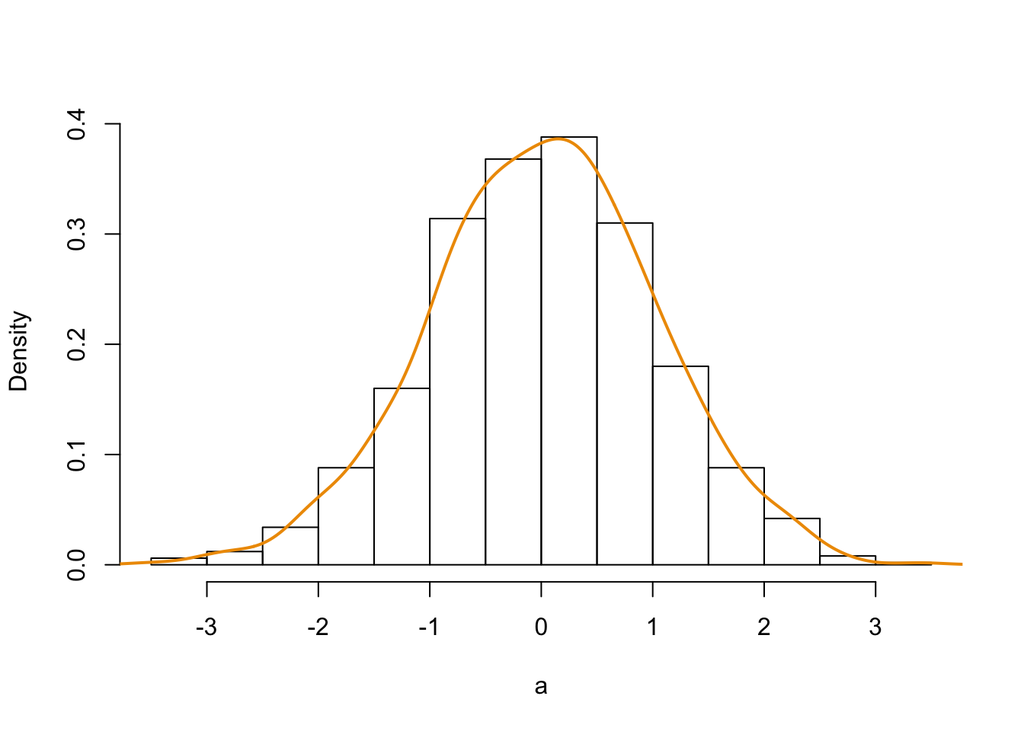

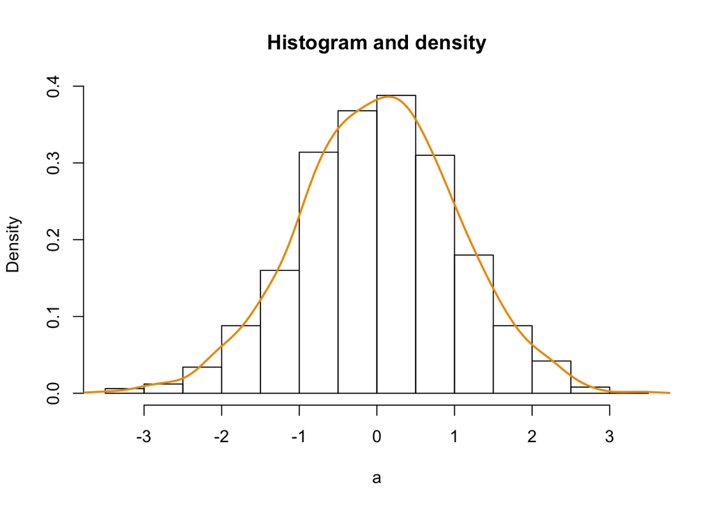

### 7.4.1 좌우 정렬

- 그래프의 좌우 정렬은 `fig.align=` 옵션을 사용한다.
- 다음에 사용하는 `diamonds` 데이터셋은 ggplot2 패키지에 포함되어 있다.
- `fig.align='center'`로 지정해 보았다.

````
```{r fig.align='center'}
ggplot(diamonds, aes(carat, price))+geom_point(col='deeppink')
```
````

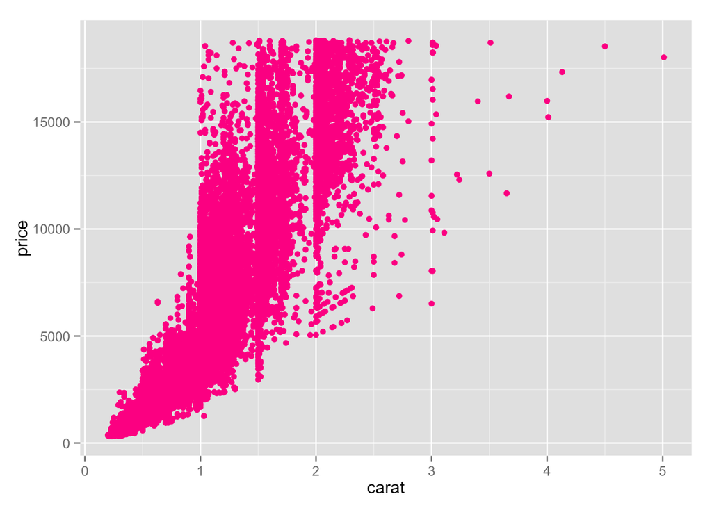

### 7.4.2 코드와 그래프의 상대적 위치

- 말로 하는 것보다 직접 옵션을 변경해 보면 쉽게 이해된다.
- `fig.show=`라는 옵션을 쓰는데, 디폴트 출력(`fig.show=‘asis’)은 그래프를 출력하는 코드 다음에 바로 그래프가 나온다. 청크의 코드는 앞에서도 사용한 적이 있는 코드이다.

[output not shown]

[output not shown]

[output not shown]

[output not shown]

- 만약, 이것은 ‘fig.show=’hold’`로 바꾸면 아래와 같이 코드 청크가 모두 출력되고 나서, 그래프는 붙잡고 있다가 한꺼번에 출력된다.

[output not shown]

### 7.4.3 복수의 그래프 레이아웃 설정

- 아래의 코드청크는 모두 4개의 그래프를 출력한다.
- 디폴트 레이아웃은 좌우 폭이 여유가 있으면 자동적으로 맞춰진다.
- 이 코드 청크와 같이 전통적인 R 그래픽 시스템으로 만들어 지는 그래프(hist() 함수 사용)과 그리드 그래픽스로 만들어지는 그래프를 배치할 때는 이 디폴트 방법이 매우 유용하다.
- 책에서 설명한 것과 같이 전통적인 그래픽 시스템과 그리드 시스템을 하나의 그래칙 창에 혼용할 수 없다. 물론 gridBase 같은 패키지를 이용하면 가능하다.

````
```{r fig.show='hold', out.width="24%"}
set.seed(2)
library(ggplot2)
a <- rnorm(1000, mean=58, sd=4)
hist(a)
df <-data.frame(a)
p <-ggplot(df, aes(a))+geom_histogram(binwidth=1,
                          fill='white', color='black',
                          aes(y=..density..))
p
p <-p + geom_density(fill="red", alpha=0.1, col='red' )
p
p <-p + geom_vline(aes(xintercept=mean(a)),
                   col='red', linetype='dashed')
p
```
````

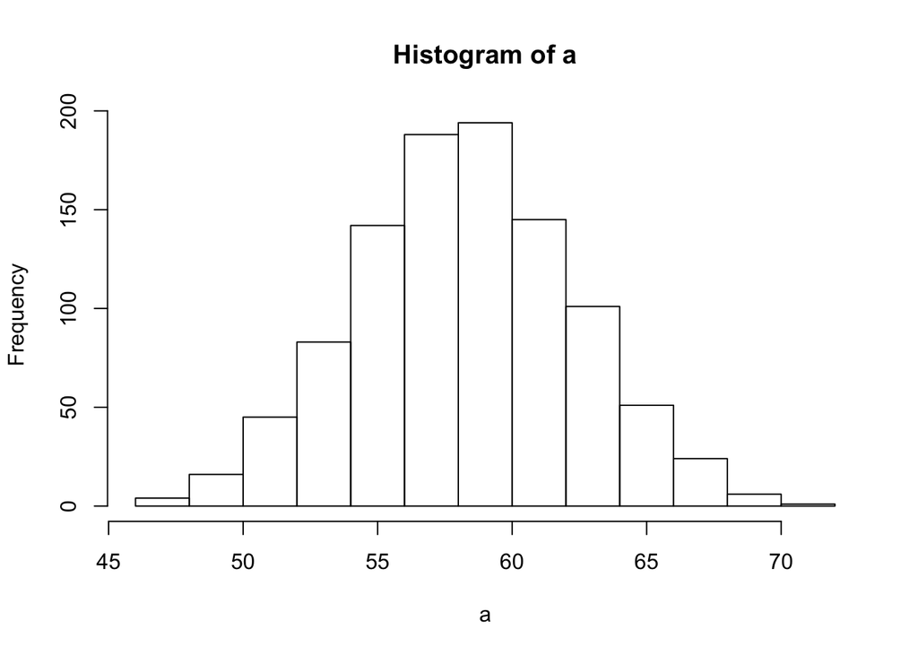

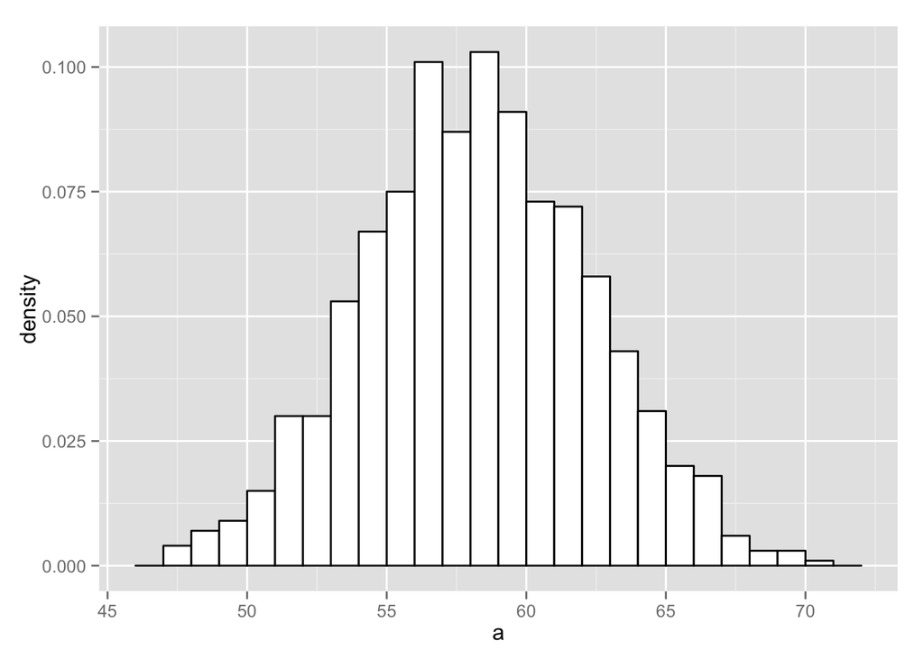

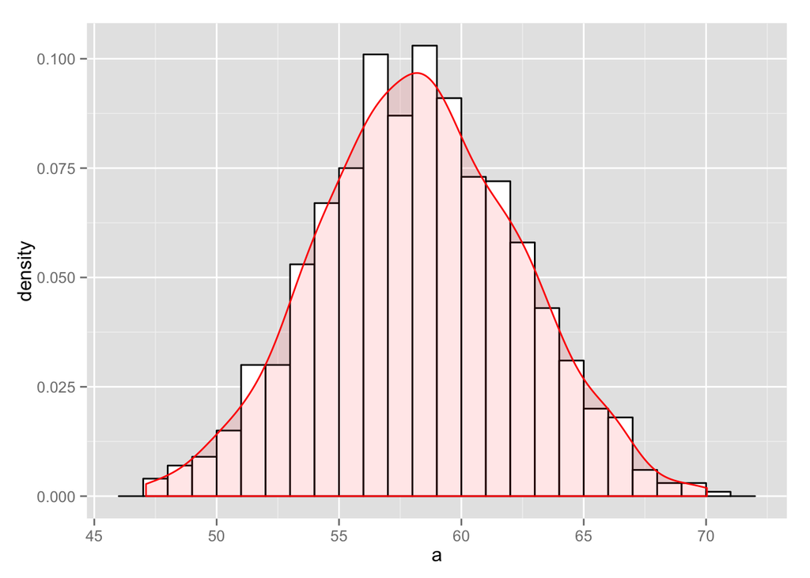

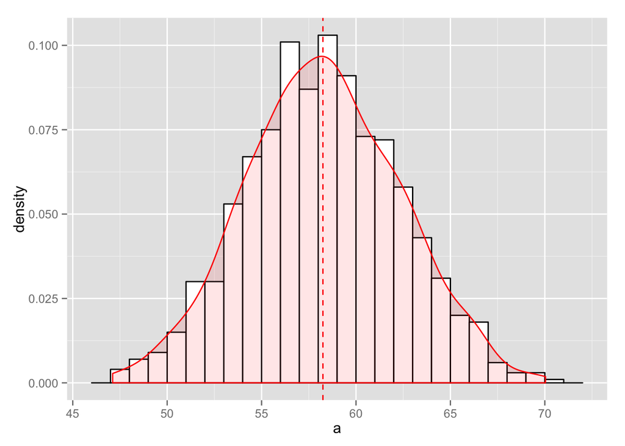

### 7.4.4 gridExtra 패키지를 이용한 그리프 그래프 레이아웃 설정

- 다수의 그리드 그래픽을 출력하는 경우 `gridExtra` 패키지를 사용하면 원하는 형태로 그래프를 배치할 수 있다.
- 아래 코드 청크에서 `HSAUR2` 패키지는 `water`라는 데이터셋을 사용하기 위해서 로딩하였다.

````
```{r fig.show='hold', message=FALSE}
library(HSAUR2)
library(grid)
library(ggplot2)
library(gridExtra)
p1 <- ggplot(water, aes(hardness, mortality)) + stat_smooth(method='lm')
p1 <- p1 + geom_point(aes(col=location))+scale_x_continuous(limits=c(0,150))+ theme(legend.position=c(0.85, 0.8))
p2 <- ggplot(water, aes(hardness))+geom_histogram(binwidth=20, fill="darkgray")+scale_x_continuous(limits=c(0,150))
p3 <- grid.rect(gp=gpar(col="white"))
p4 <- ggplot(water, aes(location,mortality))+geom_boxplot() + theme(axis.title.y=element_blank())
grid.arrange(p2, p3, p1, p4, ncol=2)
```
````

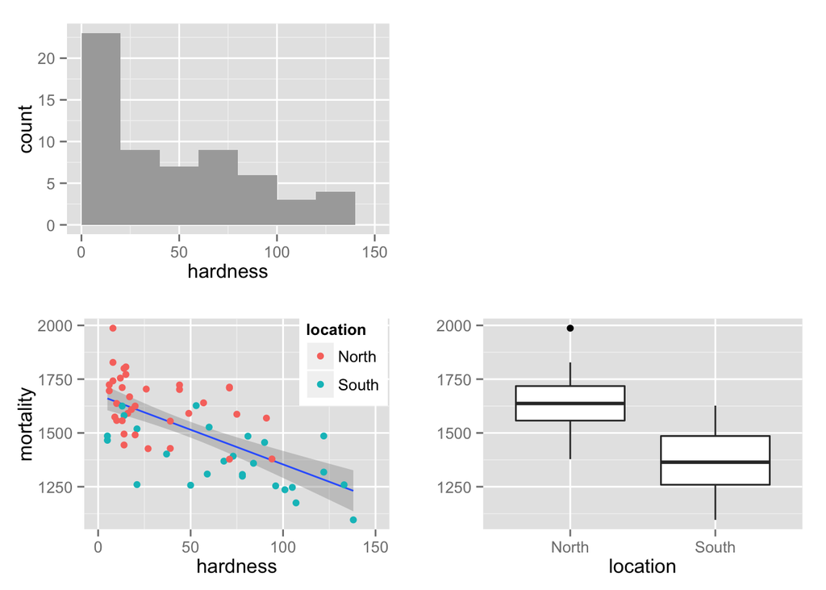

### 7.5 캡션과 레이블

````
```{r fig.cap="난수 히스토그램", fig.width=5, fig.height=4}
hist(rnorm(1000))
```
````

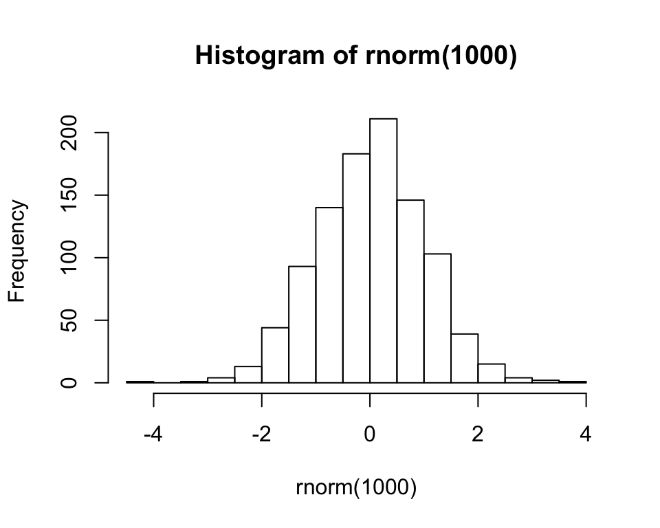

- 현재 파일(`7.3.Rmd`) 파일을 컴파일하면 `7.3.md` 파일이 만들어진다. 이 부분에 해당되는부분을 보면 아래와 같은 코드를 볼 수 있다.

```
![난수 히스토그램](figure/unnamed-chunk-12.png)
```

- 즉, `fig.cap`이라고 옵션으로 준 것은 마크다운은 링크텍스트로 사용되는 것을 볼 수 있다.
- 이것이 최종 `7.3.html`을 브라우저로 열었을 때 보이지 않는 이유는이 부분이 img 태그의 alt 특성 값으로 들어가기 때문이다. 이 alt 특성은 브라우저에서 그림을 보여줄 수 없을 때 대신 보여주는 텍스트 역할을 하도록 되어 있다.

### 그래프에 한글 삽입

- 그래프에 한글을 효율적으로 사용하기 위해서는 `extrafont` 패키지를 권장한다.
- 패키지 설정은 다음과 같이 한다.

````
```{r eval=FALSE}
 install.packages(c("extrafont", "extrafontdb", "Rttf2pt1"))
```
````

- 패키지를 로딩하고 시스템에 있는 폰트를 읽어 들인다 폰트를 읽어 오는 데는 시간이 걸린다.
- 이렇게 읽어들인 폰트는 폰트 데이터베이스에 저장되어 처음에는 이 과정이 필요하지만, 나중에는 `extrafont` 패키지만 로딩하면 된다. 처음만 시간이 걸린다.

````
```{r eval=FALSE}
library(extrafont)
font_import()
```
````

- `extrafont` 패키지 로딩하고 어떤 폰트가 가능한 지는 다음 함수로 알 수 있다.

````
```{r eval=FALSE}
fonts()
```
````

- `extrafont`를 사용할 때 많은 경고문들이 나오는 데, 이것은 아래와 같이 `warning=FALSE`라는 옵션으로 출력되지 않게 한다.
- 현재의 컴퓨터에 `나눔고딕`체가 들어 있어서 이것을 사용한다.
- 컴퓨터마다 설치되어 있는 폰트가 다를 수 있어서 아래 코드 청크는 처음 컴파일할 때 오류가 일어나지 않도록 `eval=FALSE` 옵션을 주었다.
- 실제 효과를 확인하기 위해서는 이 옵션을 지우고, 자신의 컴퓨터에서 사용가능한 폰트이름을 주어야 한다.

````
```{r warning=FALSE, eval=FALSE}
a<-rnorm(1000)
hist(a, main="히스토그램", family='나눔고딕')
```
````

- ggplot2 패키지에서는 폰트 등을 정할 때 `theme`을 사용한다.

````
```{r warning=FALSE, eval=FALSE}
p <- ggplot(mtcars, aes(x = wt, y = mpg)) + geom_point()
p <- p + ggtitle("한글 제목")
p <- p + theme(text=element_text(family="나눔명조"))
p
```
````